# Nicht so eindimensional! Vom Arbeiten mit multi-dimensionalen Daten

[figure not shown]

(Quelle: https://xkcd.com/721/, [Creative Commons Attribution-NonCommercial 2.5](https://creativecommons.org/licenses/by-nc/2.5/))

## Dimensionen von Umweltdaten

### Eindimensional

Bislang haben wir in diesem Kurs viel mit Zeitreihen gearbeitet. Zeitreihen sind ein Beispiel für eindimensionale Daten: Es wird die Dynamik einer oder mehrerer Variablen entlang der Dimension "Zeit" betrachtet.

[figure not shown]

### Zweidimensional

In den Umweltwissenschaften haben wir es auch oft mit mehrdimensionsionalen Daten zu tun: So sind Umweltvariablen wie z.B. die Geländehöhe typischerweise entlang von zwei horizontalen Raumdimensionen ausgeprägt. Einen entsprechenden Datensatz nennt man dann typischerweise ein "Digitales Geländemodell" (DGM).

[figure not shown]

### Dreidimensional

Während man die Geländehöhe über bestimmte Zeiträume als konstant annehmen kann, sind viele Umweltvariablen variabel in der Zeit *und* im horizontalen Raum. Beispiele sind Niederschlag, Landbedeckung, Bodenfeuchte u.v.a. Solche Daten lassen sich dann dreidimensional strukturieren, wobei die erste Dimension oft die Zeitdimension ist und die beiden anderen Dimensionen den horizontalen Raum abbilden. Das folgende Bild zeigt z.B. den zeitlichen Verlauf der Waldbedeckung in Borneo.

[figure not shown]

Ein anderes Beispiel für einen dreidimensionalen Datensatz ist der Zustand eines Systems entlang aller drei Raumdimensionen, also z.B. die Temperatur der Atmosphäre in Länge, Breite und Höhe, oder die Bodenfeuchte in einem Einzugsgebiet in unterschiedlichen Tiefen.

### n-dimensional

Es kann sinnvoll sein, noch weitere Dimensionen hinzuzufügen. Wenn man in einem Klimamodell der Zustand der Atmosphäre in den drei Raumdimensionen sowie der Zeit darstellt und dann noch unterschiedliche Realisationen eines Modellensembles in einem Datensatz darstellt, so hätte man z.B. fünf Dimensionen.

## Aufgabe

Ein "array" ist, einfach gesagt, ein Datensatz mit einheitlichem Datentyp entlang beliebig vieler Dimensionen. Gib aus den folgenden mehrdimensionalen Arrays folgende Werte an:

- 1D-Array: zweites Element
- 2D-Array: zweite Zeile, dritte Spalte
- 3D-Array: zweite Zeile, zweite Spalte, äh...erste Spalte von der anderen Sorte Spalte?!

[figure not shown]

Ihr seht: Allein die Terminologie wird ab der dritten Dimension nicht ganz trivial. Der Einfachheit halber bietet es sich an, die Dimensionen einfach durchzunummerieren. In Python ist jedoch stets zu beachten: Beim durchnummerieren wird bei 0 begonnen...gucken wir uns gleich in Ruhe an.

## `numpy` - multi-dimensionale Daten effizient verarbeiten

`numpy` ist in Python das Schlüsselmodul zum Arbeiten mit arrays entlang beliebiger Dimensionen. Kern ist der `numpy.ndarray` (`nd` steht für "n-dimensional") als Datentyp, der in unzähligen anderen Paketen zugrundegelegt wird.

```python
import numpy as np
```

```python
type( np.array([1,2,3]) )
```

```
numpy.ndarray
```

## Zum Aufwärmen: `numpy` in einer Dimension

```python
# 1-D Array aus einer Liste erstellen
a = np.array([1,2,3,4])
```

Nehmen wir diesen Array einmal unter die Lupe:

```python
print(a)
print("Number of dimensions:", a.ndim)
```

```
[1 2 3 4]
Number of dimensions: 1
```

### Elemente eines Arrays ansprechen: im Prinzip genauso wie bei einer `list`

```python
# Das zweite Element ansprechen ( Index 1 entspricht der zweiten Position!!)
a[1]
```

```
2
```

```python
# Das letzte Element ansprechen
a[-1]
```

```
4
```

```python
# Alle Elemente ansprechen
a[:]
```

```
array([1, 2, 3, 4])
```

```python
# Von der zweiten bis zur dritten Position
# ACHTUNG: Man gibt als rechte Grenze also immer die Position an, die NICHT in der Auswahl enthalten sein soll
a[1:3]
```

```
array([2, 3])
```

```python
# Von Anfang bis zur dritten Position
a[:3]
```

```
array([1, 2, 3])
```

```python
# Ab der zweiten Position
a[1:]
```

```
array([2, 3, 4])
```

```python
# Von der zweiten bis zur vorletzten Position
a[1:-1]
```

```
array([2, 3])
```

### Elemente eines Arrays manipulieren

```python
# Werte von Elementen ändern
a[1] = 99
a
```

```
array([ 1, 99,  3,  4])
```

```python
# Mehrere Elemente auf einmal ändern
a[:2] = 999
a
```

```
array([999, 999,   3,   4])
```

### Mit Arrays arbeiten

Der große Unterschied zum Datentyp `list`: **Man kann mit Arrays rechnen**.

```python
# Addition von zwei Listen
[1,2,3] + [1,2,3]
```

```
[1, 2, 3, 1, 2, 3]
```

```python
# Addition von zwei Arrays
np.array([1,2,3]) + np.array([1,2,3])
```

```
array([2, 4, 6])
```

```python
# Einen array mit aufsteigenden Werte erstellen
b = np.arange(5)
# Einen array aus Einsen erstellen, genauso lang wie `b`
c = np.ones(len(b))
print("b = ", b)
print("c = ", c)
# Eine Operation mit diesen Arrays
print("b + 2 * c = ", b + 2 * c)
```

```
b =  [0 1 2 3 4]
c =  [1. 1. 1. 1. 1.]
b + 2 * c =  [2. 3. 4. 5. 6.]
```

### Aufgabe

Wir definieren folgenden Array:

```
test = np.array([0, 1, 10, 22, 3, 99])
```

Sage nun den Output folgender Operationen voraus (schreibe die Lösung auf ein Papier):

- `test[1]`
- `test[-1]`
- `test[0:3] * 2`
- `test - test`
- `test[2:-1]`
- `test - np.arange(len(test)`

Überprüfe nun Deine Lösung, indem Du in der untenstehenden Zelle den Array definierst und dann die Operationen ausführst. Vieviel Prozent hast Du richtig vorhergesagt?

#### Lösung

```python
test = np.array([0, 1, 10, 22, 3, 99])
print(test[1])
print(test[-1])
print(test[0:3] * 2)
print(test - test)
print(test[2:-1])
print(test - np.arange(len(test)))
```

```
1
99
[ 0  2 20]
[0 0 0 0 0 0]
[10 22  3]
[ 0  0  8 19 -1 94]
```

## Exkurs: Funktionen vs. Methoden

Du hast jetzt schon des Öfteren mit "Funktionen" und "Methoden" gearbeitet. Du kannst Dir eine *Methode* vorstellen wie eine Funktion, die an einem Objekt, z.B. an einem `ndarray`, einem `DataFrame` oder einem `str` "dranhängt". Oft ist es egal, ob Du ein Objekt mit seiner Methode oder der entsprechenden Funktion verarbeitet.

Unverständlich? Also lieber am Beispiel:

```python
# Ein Array
x = np.array([1,2,3])
```

```python
# Anwendung der Funktion "sum"
np.sum(x)
```

```
6
```

```python
# Anwendung der Methode "sum"
x.sum()
```

```
6
```

```python
# Am Beispiel eines Strings
x = "Neiekoelaeuese"
# Methode replace
print( x.replace("e","") )
# Funktion replace
print( str.replace(x, "e", "") )
```

```
Nikolaus
Nikolaus
```

**Fazit**: Meist ist es egal, ob Du eine Funktion oder eine Methode anwendest. Oft ist es bequemer, die Methode zu verwenden, aber nicht alle Funktionen stehen als Methoden zur Verfügung. Wie immer gilt: Alles Gewöhnungssache.

## `numpy`-Arrays mit mehreren Dimensionen

### Wir bringen uns in `shape`

```python
# Wir erstellen zunächst 1-D array
d1 = np.arange(24)
d1
```

```
array([ 0,  1,  2,  3,  4,  5,  6,  7,  8,  9, 10, 11, 12, 13, 14, 15, 16,
       17, 18, 19, 20, 21, 22, 23])
```

```python
# Und machen aus diesem einen 3-D array
#   - mit 2 Elementen in der ersten Dimension,
#   - 3 in der zweiten,
#   - 4 in der dritten
d3 = d1.reshape((2,3,4))
d3
```

```
array([[[ 0,  1,  2,  3],
        [ 4,  5,  6,  7],
        [ 8,  9, 10, 11]],

       [[12, 13, 14, 15],
        [16, 17, 18, 19],
        [20, 21, 22, 23]]])
```

```python
d1.ndim, d3.ndim
```

```
(1, 3)
```

Mit dem `reshape`-Befehl kann man also einen Array in "Form" bringen, ihm also eine andere Dimension geben.

Wir können die "Form" des Arrays mit dem `shape` Befehl überprüfen.

```python
d3.shape
```

```
(2, 3, 4)
```

### Elemente auswählen

Das Ansprechen der Elemente eines mehrdimensionalen Arrays folgt im Prinzip der Intuition, kann aber schnell zum Braintwister werden...schaut's Euch am Besten *in Ruhe* an.

```python
d3[:]
```

```
array([[[ 0,  1,  2,  3],
        [ 4,  5,  6,  7],
        [ 8,  9, 10, 11]],

       [[12, 13, 14, 15],
        [16, 17, 18, 19],
        [20, 21, 22, 23]]])
```

```python
d3[0,:,:]
```

```
array([[ 0,  1,  2,  3],
       [ 4,  5,  6,  7],
       [ 8,  9, 10, 11]])
```

```python
d3[0,1:3,:]
```

```
array([[ 4,  5,  6,  7],
       [ 8,  9, 10, 11]])
```

```python
d3[0,1:3,2:4]
```

```
array([[ 6,  7],
       [10, 11]])
```

Ansonsten funktioniert auch die Zuweisung genau so wie zuvor:

```python
d3[0,1:3,2:4] = -99
d3
```

```
array([[[  0,   1,   2,   3],
        [  4,   5, -99, -99],
        [  8,   9, -99, -99]],

       [[ 12,  13,  14,  15],
        [ 16,  17,  18,  19],
        [ 20,  21,  22,  23]]])
```

```python
# Wir können auch mit Boolschen Arrays mit gleichem shape auswählen
d3[d3>18]
```

```
array([19, 20, 21, 22, 23])
```

### Aufgabe

Stelle Dir den folgenden 3-D Array `x` mal als eine Zeitreihe von Niederschlagsgittern vor, also einer flächenhaften Darstellung des Niederschlags über die Zeit. Sagen wir: 4 Zeitschritte, 3 Zeilen, 2 Spalten.

```python
np.random.seed(42)
x = np.random.lognormal(1, 2, size=(4,3,2)).astype(int)
x
```

```
array([[[ 7,  2],
        [ 9, 57],
        [ 1,  1]],

       [[63, 12],
        [ 1,  8],
        [ 1,  1]],

       [[ 4,  0],
        [ 0,  0],
        [ 0,  5]],

       [[ 0,  0],
        [50,  1],
        [ 3,  0]]])
```

Wähle nun der Reihe nach folgende Elemente aus:

- Alle Elemente des dritten Zeitschritts
- Alle Elemente der zweiten Spalte
- Im zweiten Zeitschritt die zweite Zeile und erste Spalte
- Alle Elemente > 0

#### Lösung

```python
print(x[2])
print(x[:,:,1])
print(x[1,1,0])
print(x[x>0])
```

```
[[4 0]
 [0 0]
 [0 5]]
[[ 2 57  1]
 [12  8  1]
 [ 0  0  5]
 [ 0  1  0]]
1
[ 7  2  9 57  1  1 63 12  1  8  1  1  4  5 50  1  3]
```

### Die `axis` des Guten - Funktionen entlang von Dimensionen anwenden

Eine große Stärke von `numpy` ist die Anwendung von Funktionen entlang einer Dimension. Auch hier lieber am Beispiel der Funktion `sum`:

```python
x = np.ones((3,2), dtype="int")
x
```

```
array([[1, 1],
       [1, 1],
       [1, 1]])
```

```python
# Summe ALLER Elemente
x.sum()
```

```
6
```

```python
# Summe über alle Zeilen (axis = 0)
x.sum(axis=0)
```

```
array([3, 3])
```

```python
# Summe über alle Spalten (axis = 1)
x.sum(axis=1)
```

```
array([2, 2, 2])
```

Das `axis`-Argument spezifiziert also immer die Dimension (Achse), die durch eine Operation "wegfallen" soll. Diese Funktionalität ist sehr mächtig und vor allem schnell und bequem.

### Aufgabe

Nehmen wir einmal an, beim Array `x` handelt es sich um Messdaten für 10 Zeitschritte für 5 Sensoren. Wir stellen uns mal einen Beispieldatensatz her:

```python
x = np.random.uniform(-1, 1, size=(10,5)).round(1)
x[x < 0] = np.nan
x
```

```
array([[ 0.2,  nan,  0.2,  nan,  nan],
       [ 0.9,  0.9,  0.6,  nan,  nan],
       [ 0.4,  nan,  nan, -0. ,  nan],
       [ 0.8,  nan,  0.3,  nan,  0. ],
       [ 0.1,  nan,  0.9,  0.6,  0.9],
       [ 0.8,  0.2,  0.8,  nan,  nan],
       [ nan,  nan,  nan,  nan,  0.7],
       [ nan,  nan,  0.1,  nan,  0.6],
       [ nan,  1. ,  0.5,  nan,  nan],
       [ 0.6,  0.4,  0.5,  0.5,  nan]])
```

Leider fallen die Sensoren oft aus. Du möchtest Dir einen Überblick über die Datenverfügbarkeit verschaffen. Gebe für jeden Zeitschritt die Summe der Fehlwerte aus. Nutze dafür zunächst `np.isnan` und dann `np.sum`

#### Lösung

```python
np.isnan(x).sum(axis=1)
```

```
array([3, 2, 3, 2, 1, 2, 4, 3, 3, 1])
```

## Wie bekomme ich überhaupt meine Daten in einen `numpy`-Array?

Es gibt viele Möglichkeiten, Daten in einen `ndarray` zu bringen. Im Wesentlichen unterscheiden wir zwei Szenarien:

1. Array selbst erstellen
2. Daten aus Dateien einlesen

### Arrays selbst erstellen

Wir haben bereits verschiedene Wege kennengelernt, Arrays mit einem definierte `shape` zu erstellen und damit weiterzuarbeiten.

```python
# Array aus Einsen
np.ones(shape=(2,2), dtype=int)
```

```
array([[1, 1],
       [1, 1]])
```

```python
# Array aus Nullen
np.zeros(shape=(2,2), dtype=int)
```

```
array([[0, 0],
       [0, 0]])
```

```python
# Länge des Arrays sowie Start- und Endpunkt (beide inklusive) vorgeben
np.linspace(start=1, stop=11, num=5)
```

```
array([ 1. ,  3.5,  6. ,  8.5, 11. ])
```

```python
# Start- und Endpunkt (exklusive) sowie Schrittweite vorgeben
np.arange(start=1, stop=11, step=2.5)
```

```
array([1. , 3.5, 6. , 8.5])
```

```python
# Zufallszahlen: Gleichverteilung
np.random.uniform(0,1,size=(2,2))
```

```
array([[0.35846573, 0.11586906],
       [0.86310343, 0.62329813]])
```

### Arrays aus Dateien einlesen

Bevor wir jetzt viele Beispiele behandeln: Die meisten Pythonpakete, die regelmäßige, mehrdimensionale Daten aus Dateien einlesen, geben diese als `ndarray` zurück. Das können Pakete zum Einlesen von Rasterdaten, Bildern usw. sein. Wir lernen nun ein besonderes Format kennen, das im wissenschaftlichen Bereich große Bedeutung gewonnen hat: das NetCDF-Format ("Network Common Data Form").

## Anwendungsbeispiel: Schneeklimatologie in Europa mit ERA5

ERA5 ist das jüngste globale Reanalyseprodukt des ECMWF (European Centre for Medium-Range Weather Forecasts). Aber was ist eigentlich eine Reanalyse? Schaut Euch bitte zunächst das folgende Video an, dass wir mit etwas jupyter-Hokuspokus direkt einbinden können.

```python
from IPython.display import HTML
```

```python
HTML('<iframe width="560" height="315" src="https://www.youtube.com/embed/FAGobvUGl24" title="YouTube video player" frameborder="0" allow="accelerometer; autoplay; clipboard-write; encrypted-media; gyroscope; picture-in-picture" allowfullscreen></iframe>')
```

[video not shown]

Wir verwenden in diesem Kurs "ERA5-Land", ein räumlich höher aufgelöstes Spezialprodukt, welches Klimavariablen für die Landoberfläche bereitstellt. Die Daten sind zwar stündlich, aber wir nutzen das Produkt mit monatlichen Mittelwerten, um die Datenmenge zu reduzieren. Auch nutzen wir nur ein Fenster über Europa.

Die Daten können [hier](https://cds.climate.copernicus.eu/cdsapp#!/dataset/reanalysis-era5-land?tab=overview) heruntergeladen werden - Ihr müsst Euch für den Download allerdings bei Copernicus registrieren. Aber das [Formular](https://cds.climate.copernicus.eu/cdsapp#!/dataset/reanalysis-era5-land?tab=form) für die Auswahl der Daten könnt Ihr Euch auch so anschauen. Eine Beschreibung der verfügbaren Parameter aus ERA5-Land gibt es [hier](https://confluence.ecmwf.int/display/CKB/ERA5-Land%3A+data+documentation#ERA5Land:datadocumentation-parameterlistingParameterlistings).

Wir haben für unser Beispiel die Parameter Schneebedeckung (`snowc`) und Temperatur in 2m Höhe (`t2m`) heruntergeladen. Das sind für Europa allein immerhin schon über 300 MB.

### Lesen der Daten aus einer NetCDF-Datei

Ohne hier in die Tiefe zu gehen, lernen wir ein wichtiges Datenformat zur Speicherung mehrdimensionaler Daten kennen, das `netcdf`-Format. Wir nutzen dazu das Paket [netCDF4](https://unidata.github.io/netcdf4-python/#tutorial).

```python
import netCDF4 as nc
```

```python
era5 = nc.Dataset("../data/era5_2mtemp_and_snowcover.nc", "r", format="NETCDF4")
```

Das Besondere am NetCDF-Format ist, dass die Daten bereits entlang der Dimensions strukturiert sind. Diese Dimesionen kann man sich wie folgt anzeigen lassen:

```python
era5.dimensions
```

```
{'longitude': <class 'netCDF4._netCDF4.Dimension'>: name = 'longitude', size = 401,
 'latitude': <class 'netCDF4._netCDF4.Dimension'>: name = 'latitude', size = 401,
 'time': <class 'netCDF4._netCDF4.Dimension'>: name = 'time', size = 485}
```

Wir haben also die Dimensionen `latitude`, `longitude` und `time`. Entlang dieser Dimensionen kann eine NetCDF-Datei beliebig viele Variablen (i.e. Daten) bereithalten. Einen Überblick gibt uns das Attribut `variables`.

```python
era5.variables
```

```
{'longitude': <class 'netCDF4._netCDF4.Variable'>
 float32 longitude(longitude)
     units: degrees_east
     long_name: longitude
 unlimited dimensions:
 current shape = (401,)
 filling on, default _FillValue of 9.969209968386869e+36 used,
 'latitude': <class 'netCDF4._netCDF4.Variable'>
 float32 latitude(latitude)
     units: degrees_north
     long_name: latitude
 unlimited dimensions:
 current shape = (401,)
 filling on, default _FillValue of 9.969209968386869e+36 used,
 'time': <class 'netCDF4._netCDF4.Variable'>
 int32 time(time)
     units: hours since 1900-01-01 00:00:00.0
     long_name: time
     calendar: gregorian
 unlimited dimensions:
 current shape = (485,)
 filling on, default _FillValue of -2147483647 used,
 't2m': <class 'netCDF4._netCDF4.Variable'>
 int16 t2m(time, latitude, longitude)
     scale_factor: 0.0009662785982020747
     add_offset: 280.1167577664626
     _FillValue: -32767
     missing_value: -32767
     units: K
     long_name: 2 metre temperature
 unlimited dimensions:
 current shape = (485, 401, 401)
 filling on,
 'snowc': <class 'netCDF4._netCDF4.Variable'>
 int16 snowc(time, latitude, longitude)
     scale_factor: 0.0015259487586406848
     add_offset: 49.99923702562068
     _FillValue: -32767
     missing_value: -32767
     units: %
     long_name: Snow cover
 unlimited dimensions:
 current shape = (485, 401, 401)
 filling on}
```

### Aufgabe

Du siehst, dass auch die Dimensionen als Variablen abgelegt sind. Schau Dir nun den Output des Befehls `era5.variables` genauer an: Welche Einheiten haben die Variablen - und welchen `shape`?

#### Lösung

- `longitude`, *unit:* degrees east, *shape:* (401,)
- `latitude`, *unit:* degrees north, *shape:* (401,)
- `time`, *unit:* hours since 1900-01-01 00:00:00.0, *shape:* (485,)
- `t2m` (2 metre temperature), *units:* Kelvin, *shape:* (485, 401, 401)
- `snowc` (Snow cover), *unit:* %, *shape:* (485, 401, 401)

### Analyse der Schneebedeckung

```python
import matplotlib.pyplot as plt
```

Um einen groben Überblick über die räumlichen Verhältnisse zu erhalten, berechnen wir zunächst den Mittelwert der Schneebedeckung (`snowc`) über den gesamten Zeitraum für jede Gitterzelle. Da die Zeit die erste Dimension ist, berechnen wir den Mittelwert (`mean`) entlang der ersten Dimension (`axis=0`).

Wir sehen an diesem Beispiel auch gleich, wie wir auf die Daten im NetCDF zugreifen: `{NetCDF-Objekt}["{Variable}"][:]`.

Das nachgestellte `[:]` ist der Schlüssel, um auf die Daten als `ndarray` zuzugreifen. Von da an ist alles Routine...

```python
snowc_time_avg = era5["snowc"][:].mean(axis=0)
```

Eine schnelle Möglichkeit zum Plotten regelmäßiger Gitter bietet die `matplotlib`-Funktion `imshow`.

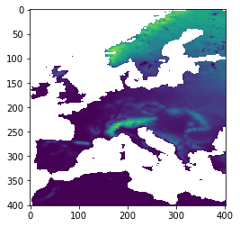

```python
cp = plt.imshow(snowc_time_avg)
```

Wir würden hier gern noch die Achsen mit sinnvollen Ticklabels versehen. Dafür gibt es unterschiedliche Kniffe. Wir geben hier einfach die räumliche Bounding Box (`[x_min , x_max, y_min , y_max]`) an, die wir aus den Variablen `latitude` und `longitude` konstruieren.

```python
bbox = [era5["longitude"][:].min(),
        era5["longitude"][:].max(),
        era5["latitude"][:].min(),
        era5["latitude"][:].max()]
```

Also nochmal in schicker...

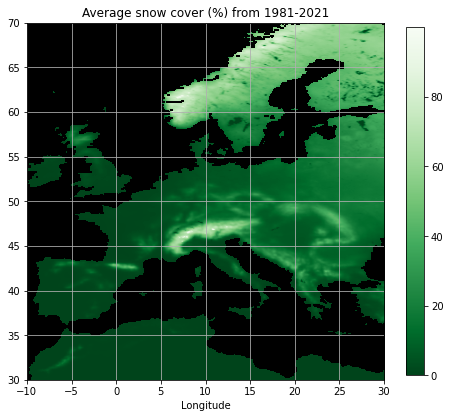

```python
fig = plt.figure(figsize=(8,8))
cmap = plt.cm.get_cmap("Greens_r").copy()
cmap.set_bad('black',1.)
cp = plt.imshow(snowc_time_avg, extent=bbox, cmap=cmap)
#fig.set_facecolor("black")
plt.xlabel("Latitude")
plt.xlabel("Longitude")
plt.grid()
plt.colorbar(cp, shrink=0.8)
_ = plt.title("Average snow cover (%) from 1981-2021")
```

### Aufgabe

Stelle nun den Zusammenhang zwischen Breitengrad und Schneebedeckung dar, mit anderen Worten: Berechne den Mittelwert der Schneebedeckung entlang der Dimensionen `time` und `longitude` und plotte dann den resultieren 1-D Array gegen die Dimension `latitude`. **Hinweis**: Das `axis`-Argument kann mehrere Dimensionen enthalten. Mit `axis=(0,1)` "reduziert" man z.B. die Dimensionen `0` und `1` gleichzeitig.

#### Lösung

```python
snowc_time_long_avg = era5["snowc"][:].mean(axis=(0,2))
```

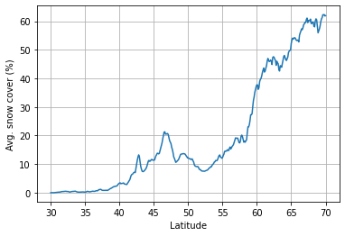

```python
plt.plot(era5["latitude"][:], snowc_time_long_avg)
plt.xlabel("Latitude")
plt.ylabel("Avg. snow cover (%)")
plt.grid()
```

## Vertiefungsaufgabe

Mal wieder Klimawandel: Stelle den zeitlichen Verlauf der mittleren Schneebedeckung dar. Dafür brauchst Du einen `datetime` Array. Die Variable `time` ist ein bisschen spröde...sie stellt Stunden seit dem 1. Januar 1900 dar. Die Umwandlung in einen Array von `datetime` schenken wir Dir...und nehmen `pandas` zur Hilfe.

```python
import pandas as pd
```

```python
dtimes = pd.to_datetime(era5["time"][:].astype(np.int64)*3600, unit="s", origin="1900-01-01T00:00:00")
```

Anmerkung: Wer sich fragt, warum wir nochmal eine Typkonvertierung mit `astype(np.int64)` machen, kann diese ja mal rauslöschen und schauen, was passiert. Stichwort: Overflow. Die Aufklärung für Streber:innen gibt es passenderweise bei [Stackoverflow](https://stackoverflow.com/questions/1970680/integer-overflow-in-numpy-arrays). Gut, dass wir wissen, was Datentypen sind...

**So, jetzt bist Du dran!**

### Lösung

```python
snowc_lat_long_avg = era5["snowc"][:].mean(axis=(1,2))
```

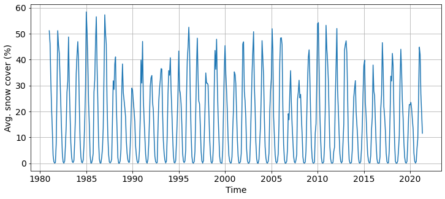

```python
plt.rcParams.update({'font.size': 14})
plt.subplots(figsize=(12,5))
plt.plot(dtimes, snowc_lat_long_avg)
plt.xlabel("Time")
plt.ylabel("Avg. snow cover (%)")
plt.grid()
```

Wir sehen hier einen klaren Jahresgang, vielleicht auch einen gewissen Trend über die Zeit? Naja, ganz schön schwierig mit den Trends, vor allem wenn die Reihe "nur" 40 Jahre lang ist. Außerdem ist zu bedenken: Es geht um Schneebedeckung, nicht um Schmelzwasseräquivalente...naja. Vertagen wir das Thema.

```python
i = np.where(era5["latitude"][:]==55.)[0][0]
j = np.where(era5["latitude"][:]==45.)[0][0]
k = np.where(era5["longitude"][:]==5.)[0][0]
m = np.where(era5["longitude"][:]==15.)[0][0]
i, j, k, m
```

```
(150, 250, 150, 250)
```

```python
snowc_me = era5["snowc"][:,i:j, k:m].mean(axis=(1,2))
```

Für die Statistik packen wir das lieber in einen DataFrame.

```python
df = pd.DataFrame({"snowc":snowc_me}, index=dtimes)
```

Jetzt wollen wir für jedes Jahr den Mittelwert und das Maximum der Schneebedeckung darstellen.

```python
# Das letzte Jahr schmeißen wir raus, weil unvollständig
dfmean = df.resample("1a").mean()[:-1]
dfmax = df.resample("1a").max()[:-1]
```

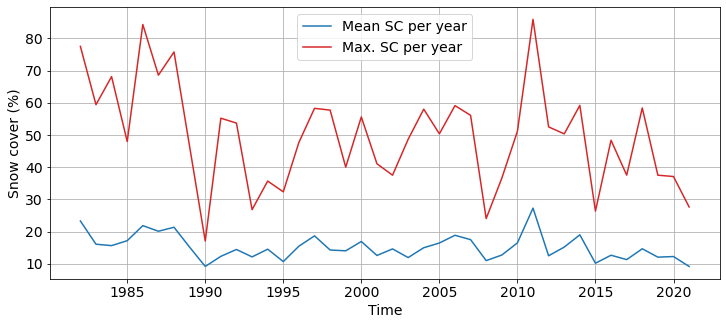

```python
plt.rcParams.update({'font.size': 14})
fig, ax = plt.subplots(figsize=(12,5))
plt.plot(dfmean.index, dfmean.snowc, color="tab:blue", lw=1.5, label="Mean SC per year")
plt.plot(dfmax.index, dfmax.snowc, color="tab:red", lw=1.5, label="Max. SC per year")
plt.xlabel("Time")
plt.ylabel("Snow cover (%)")
plt.legend()
plt.grid()
```

Naja, sieht ein bisschen langweilig aus...aber so ist das eben manchmal.

## Alles noch einfacher und mächtiger mit `xarray`

Wir haben die NetCDF-Datei mit dem Paket `netCDF4` eingelesen. Es gibt mittlerweile ein neues Paket, welches das Arbeiten mit NetCDF-Dateien dramatisch erleichtert: `xarray`. Im Prinzip könnt Ihr Euch `xarray` wie eine Kombination aus `NetCDF4` und `pandas` mit einer Vielfalt hilfreicher Werkzeuge (Methoden) vorstellen. Am Beispiel:

```python
import xarray as xr
```

```python
ds = xr.open_dataset("../data/era5_2mtemp_and_snowcover.nc")
```

```python
ds
```

```
<xarray.Dataset> Size: 1GB
Dimensions:    (time: 485, latitude: 401, longitude: 401)
Coordinates:
  * longitude  (longitude) float32 2kB -10.0 -9.9 -9.8 -9.7 ... 29.8 29.9 30.0
  * latitude   (latitude) float32 2kB 70.0 69.9 69.8 69.7 ... 30.2 30.1 30.0
  * time       (time) datetime64[ns] 4kB 1981-01-01 1981-02-01 ... 2021-05-01
Data variables:
    t2m        (time, latitude, longitude) float64 624MB ...
    snowc      (time, latitude, longitude) float64 624MB ...
Attributes:
    Conventions:  CF-1.6
    history:      2021-08-18 09:39:00 GMT by grib_to_netcdf-2.20.0: /opt/ecmw...
```

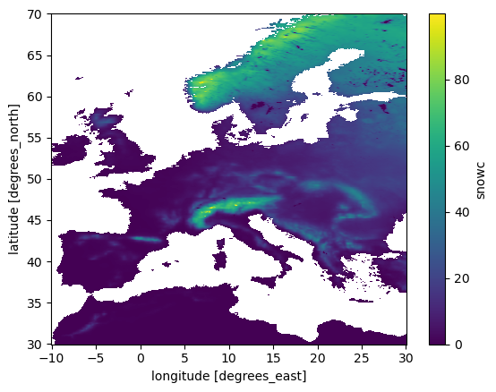

```python
# Mittelwert über den Gesamtzeitraum
ds["snowc"].mean(axis=0).plot()
```

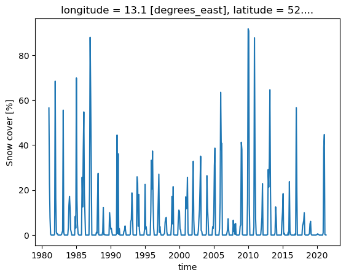

```python
# Zeitreihe für die Gitterzelle, in der sich Potsdam befindet
df = ds.sel(latitude=52.38, longitude=13.06, method="nearest")["snowc"]
df.plot()
```